# A UN Report on the Relationship between GDP and life expectancy

Cody Hager

2023-10-13

[output not shown]

```r
library(tidyverse)
library(here)
library(knitr)
```

This report was prepared to the attention of the UN. It was analyzes the relationship between a country’s GDP, its life expectancy, and C)2 emissions. Our goal is the determine to what a degree a country’s economic strength or weakness is related to its public health status and impact on climate pollution. WE hypothesize that both life and expectancy and CO2 emissions increase with the country’s GDP

```r
gapminder_1997 <- read_csv(here("data/gapminder_1997.csv"))
```

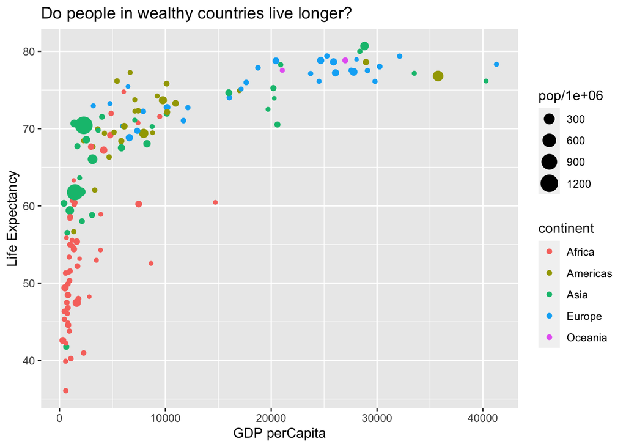

```r
n_countries <- gapminder_1997 %>%
  select(country) %>%
  n_distinct()

minimum_gdp <- gapminder_1997 %>%
  summarize(min(gdpPercap)) %>%
  round(digits = 1)

maximum_gdp <- gapminder_1997 %>%
  summarize(max(gdpPercap)) %>%
  round(digits = 1)
```

The above plot shows the relationship between GDP per capita and life expectancy for a total of 142 countries. For this set of countries, economic wealth ranged from a minium of $312.2 to a maximum of $4.12832^{4} per capita.

[output not shown]

| country | pop | continent | lifeExp | gdpPercap |
| --- | --- | --- | --- | --- |
| Australia | 18565243 | Oceania | 78.83 | 26997.94 |
| New Zealand | 3676187 | Oceania | 77.55 | 21050.41 |

# This is how to create bullet points

Also can use * for bullet point Bold and Italic *word*  
hyperlink

This is how to create heading and sub heading

# Heading 1

## Heading 2

### Heading 3

#### Heading 4

##### Heading 5

###### Heading 6